# Geometry, R, Stan, and NFL Field Goal Attempts: 1960-2019

James R Bland (https://sites.google.com/site/jamesbland/)

November 23, 2019

In [a recent blog post](https://jamesblandecon.github.io/NFLFieldGoalsExploratory.html), I downloaded data on every NFL field goal attempt since 1960, as recorded by [pro-football-reference.com](https://www.pro-football-reference.com/play-index/fg_finder.cgi). For this post, I am going to take a model of angle accuracy to the data, which will be similar to [my previous post on NBA jump shots](https://jamesblandecon.github.io/NBAJumpShotsIndividual.html), and [Andrew Gelman’s model of golf putting](https://mc-stan.org/users/documentation/case-studies/golf.html).

Here is a summary of what I downloaded (more details in the previous blog post):

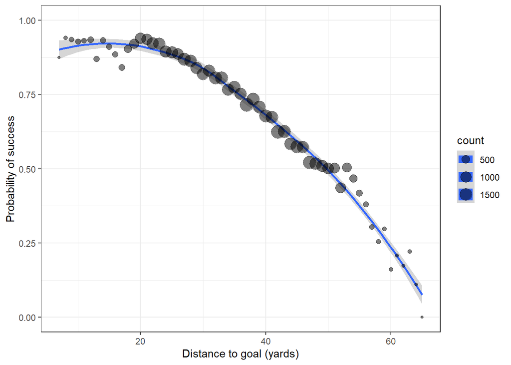

```r
AggData<-aggregate(Data[,c("Dist","Y","B")],by=list(Data$Dist),FUN=mean)

AggData$count<-aggregate(Data[,c("Dist")], by=list(Data$Dist),FUN=length)$x
AggData<-AggData[AggData$Dist<=65,]
plt<-ggplot(AggData,aes(x=Dist,y=Y,size=count))+geom_smooth(method="loess")+xlab("Distance to goal (yards)")+ylab("Probability of success")+geom_point(alpha=0.5)+ylim(0,1)
plt<-plt+theme_bw()
plt
```

# Model

A player makes a field goal attempt $x$ yards from the goal (my data). The goal posts are $d$ yards apart (given), and the crossbar is $h$ yards above the ground (I attempted to use this too, but there are not enough long shots to identify the parameters for this model, see Appendix II).

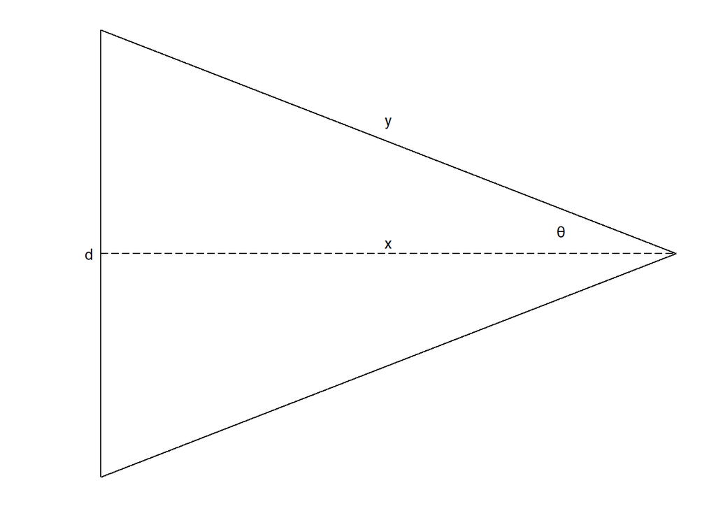

Let $y$ be the hypotenuse of the right-angled triangle made between the ball, the midpoint of the goalposts, and one of the goal posts. This hypotenuse has length: $y=\sqrt{x^2+d^2/4}$. The angle at the ball vertex of this triangle can be found by solving:
$$\begin{aligned}
x&=y\cos\theta\\
x&=\cos\theta\sqrt{x^2+d^2/4}\\
\cos\theta&=\frac{x}{\sqrt{x^2+d^2/4}}\\
\theta&=\cos^{-1}\left(\frac{x}{\sqrt{x^2+d^2/4}}\right)
\end{aligned}$$
And hence the angle of tolerance for a field goal at the $x$-yard line is $\pm\theta$.

# Estimating the model in Stan

One learning experience for me here was that Stan works much faster with count data (i.e. one row summarizes all successes and failures at 40 yards), rather than binary (i.e. each row is one attempt). So here is what I ended up with, but it’s not where I started.

```c
// FieldGoalsCount.stan
functions {


}
data {
  // Tell Stan how to read in the data
  int n; // Number of observations
  vector[n] Angle;
  int y[n]; // =count of scored
  int N[n]; // number of attempts from that distance
  real priorK[2];

}
transformed data {

}
parameters {
  real<lower=0> k;

}
transformed parameters {

}
model {
    vector[n] p;
    for (ii in 1:n) {
        p[ii] =  1-2*normal_cdf((-Angle[ii]),0.0,k);

    }


  y ~ binomial(N,p);


  }
generated quantities {

}
```

## Results

### Using all the data at once

Here are the estimation results if I use all data at once:

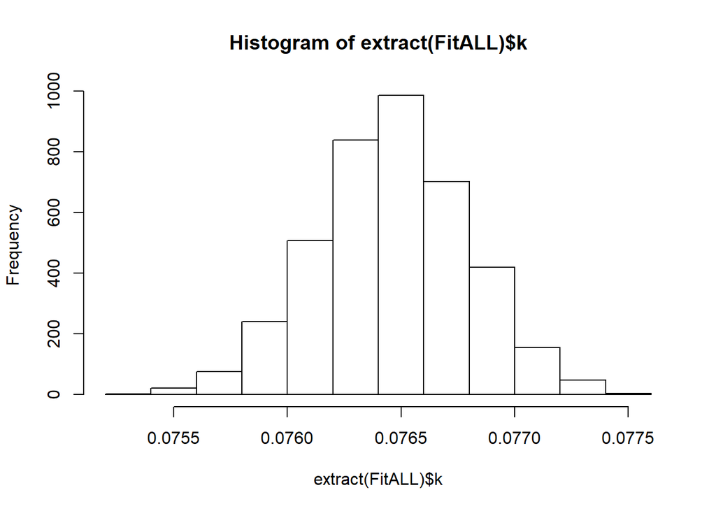

```r
hist(extract(FitALL)$k)
```

But it is more helpful to see what this means in terms of predicted probabilities.

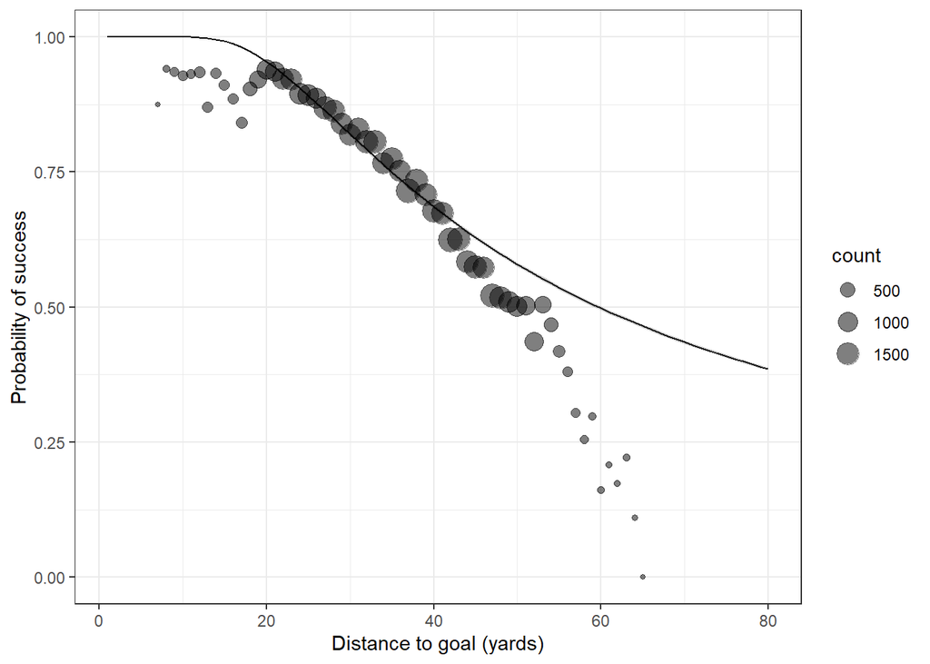

```r
k<-extract(FitALL)$k
kq1<-quantile(k,c(0.025,0.975))
kq2<-quantile(extract(FitALL)$k,c(0.25,0.75))
km<-median(k)
x<-seq(1,80)

pltData<-data.frame(x)
pltData$angle<-acos(x/sqrt(x^2+d^2/4))
pltData$pm<-1-2*pnorm(-pltData$angle/km)
pltData$p1l<-1-2*pnorm(-pltData$angle/kq1[1])
pltData$p1u<-1-2*pnorm(-pltData$angle/kq1[2])
pltData$p2l<-1-2*pnorm(-pltData$angle/kq2[1])
pltData$p2u<-1-2*pnorm(-pltData$angle/kq2[2])
plt<-ggplot(pltData,aes(x=x,y=pm))
plt<-plt+geom_line()
plt<-plt+geom_ribbon(aes(ymin=p2l,ymax=p2u),alpha=0.5)
plt<-plt+geom_ribbon(aes(ymin=p1l,ymax=p1u),alpha=0.2)
plt<-plt+theme_bw()
plt<-plt+geom_point(data=AggData,aes(x=Dist,y=Y,size=count),alpha=0.5)
plt<-plt+xlab("Distance to goal (yards)")+ylab("Probability of success")
plt
```

So it looks like the model fits pretty well in the 20-40 yards range (where most of the kicks are taken), but does not do so well outside there.

### Estimating the model for each season separately

I also estimate the model for each season individually. This way, we can see how kicking has improved over time.

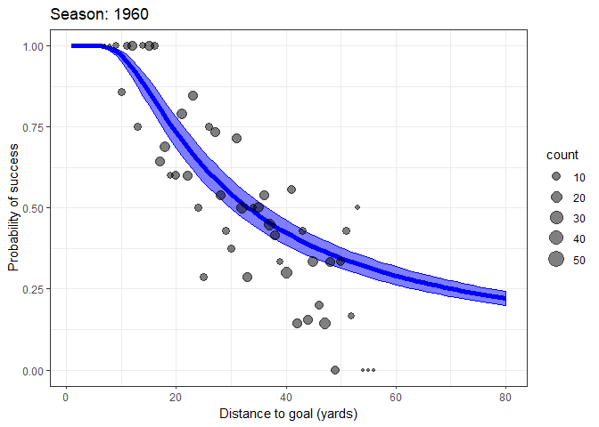

```r
AD<-aggregate(Data[,c("season","Dist","Y")],by=list(Data$season,Data$Dist),FUN=mean)
AD$count<-aggregate(Data[,c("season","Dist","Y")],by=list(Data$season,Data$Dist),FUN=length)$Y
AD<-AD[,c("season","Dist","Y","count")]
AD$x<-AD$Dist
pltData<-data.frame()
SeasonList<-seq(1960,2019)
for (xx in 1:length(x)) {
  a<-acos(x[xx]/sqrt(x[xx]^2+d^2/4))
  p<-data.frame(aggregate(SimSeason[,c("k","season")],by=list(SimSeason$season),FUN=function(z) mean(1-2*pnorm(-a/z))))$k
  pl<-data.frame(aggregate(SimSeason[,c("k","season")],by=list(SimSeason$season),FUN=function(z) quantile(1-2*pnorm(-a/z),0.025)))$k
pu<-data.frame(aggregate(SimSeason[,c("k","season")],by=list(SimSeason$season),FUN=function(z) quantile(1-2*pnorm(-a/z),0.975)))$k
  tmp<-data.frame(p,pl,pu)
  tmp$season<-SeasonList
  tmp$x<-x[xx]
  #


  pltData<-rbind(pltData,tmp)

}

pD<-merge(pltData,AD,by=c("season","x"),all=TRUE)


plt<-ggplot(pD,aes(x=x,y=p))+geom_line(color="blue",size=2)
plt<-plt+geom_ribbon(aes(x=x,ymin=pl,ymax=pu),color="blue",fill="blue",alpha=0.5)
plt<-plt+xlab("Distance to goal (yards)")+ylab("Probability of success")
plt<-plt+geom_point(aes(x=x,y=Y,size=count),alpha=0.5)
plt<-plt+transition_time(season)
plt<-plt+xlab("Distance to goal (yards)")+ylab("Probability of success")
plt<-plt+theme_bw()
plt<-plt+labs(title = 'Season: {frame_time}')
animate(plt, nframes = length(SeasonList)*2)
```

The shaded area around the line is a 95% Bayesian credible region (2.5th-97.5th percentile). So just like the pooled model, these models are doing well for the most common distances, and doing especially terribly for the long shots. In Appendix II I discuss a possible extension, but there are not much data that far away from the goal, so there isn’t much to be learned there.

Comparing the first and most recent (completed) season in the data, there has been considerable improvement!

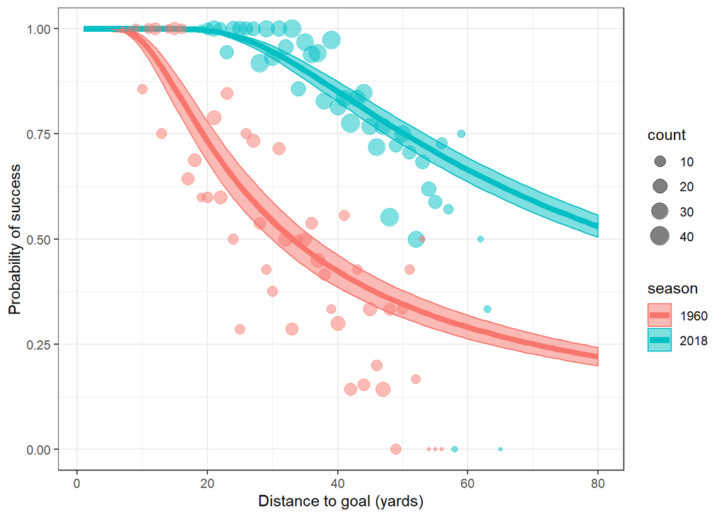

```r
pltData<-rbind(pD[pD$season==2018,],pD[pD$season==1960,])
pltData$season<-paste(pltData$season)
plt<-ggplot(pltData,aes(x=x,y=p,color=season,group=season,fill=season))+geom_line(size=2)
plt<-plt+geom_ribbon(aes(x=x,ymin=pl,ymax=pu),alpha=0.5)
plt<-plt+xlab("Distance to goal (yards)")+ylab("Probability of success")
plt<-plt+geom_point(aes(x=x,y=Y,size=count),alpha=0.5)
plt<-plt+theme_bw()
plt
```

### Estimating the model for each player separately

Finally. I can estimate the model by each player. There are over 400 of them (about 300 after I exclude those who only made 10 or fewer attempts), so I will focus on ranking the players based on their estimated probability of scoring at 50 yards.

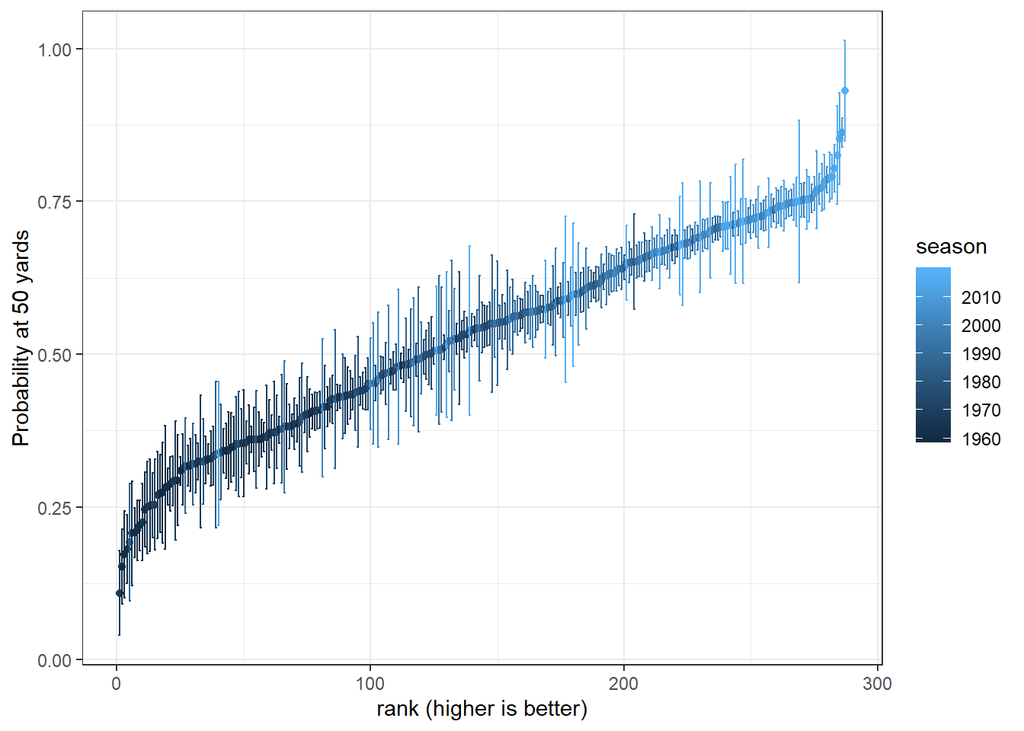

```r
SimPlayer$Pr50<-1-2*pnorm(-acos(50/sqrt(50^2+d^2/4))/SimPlayer$k)
PlayerMeans<-aggregate(SimPlayer,by=list(SimPlayer$Player),FUN= mean)
PlayerMeans$Player<-PlayerMeans$Group.1
PlayerMeans$sd<-aggregate(SimPlayer,by=list(SimPlayer$Player),FUN= sd)$Pr50
Sorted<-PlayerMeans[order(PlayerMeans$Pr50),]
Sorted$rank<-seq(1:dim(Sorted)[1])

plt<-ggplot(Sorted,aes(x=rank,y=Pr50,ymin=(Pr50-sd),ymax=(Pr50+sd),color=season))+geom_point()
plt<-plt+geom_errorbar()
plt<-plt+theme_bw()+xlab("rank (higher is better)")+ylab("Probability at 50 yards")
plt
```

Here, “season” is equal to the year in which a player first made a field goal attempt in the NFL. The error bars show $\pm1$ posterior standard deviation.

So who are the best kickers?

```r
Sorted<-PlayerMeans[order(-PlayerMeans$Pr50),]
Sorted[1:20,c("Player","season","Pr50","sd","count")]
```

```
##               Player season      Pr50         sd count
## 9     Austin Seibert   2019 0.9311748 0.08207162    16
## 165    Justin Tucker   2012 0.8623182 0.02396328   285
## 279     Travis Coons   2015 0.8528653 0.07490699    36
## 194  Michael Badgley   2018 0.8258656 0.08065563    27
## 162       Josh Lambo   2015 0.8038255 0.03835737   130
## 47     Chris Boswell   2015 0.7902075 0.03601217   146
## 285         Wil Lutz   2016 0.7893937 0.04021593   129
## 240     Robbie Gould   2005 0.7853862 0.02177464   424
## 111  Harrison Butker   2017 0.7816539 0.04494835    98
## 167      Kai Forbath   2012 0.7730071 0.03836616   137
## 259 Stephen Hauschka   2008 0.7702482 0.02513913   306
## 223   Patrick Murray   2014 0.7689488 0.06371849    47
## 58        Dan Bailey   2011 0.7631455 0.02711719   258
## 161       Josh Brown   2003 0.7549230 0.02256179   391
## 231    Randy Bullock   2013 0.7538100 0.03684639   155
## 119     Jake Elliott   2017 0.7532428 0.04873551    82
## 204  Mike Vanderjagt   1998 0.7523497 0.02797563   273
## 59     Dan Carpenter   2008 0.7518841 0.02703979   277
## 216        Nick Rose   2017 0.7500129 0.13295435    12
## 124      Jason Myers   2015 0.7491693 0.03948134   131
```

You might want to discount a few of these because there are very few observations for some.

Although Austin Siebert certainly is making a good start:

```r
Data[Data$Player=="Austin Seibert",c("Date","Opp","Dist","Good.")]
```

```
##             Date Opp Dist Good.
## 50294 2019-11-10 BUF   47     Y
## 50295 2019-11-10 BUF   27     Y
## 50296 2019-11-03 DEN   30     Y
## 50297 2019-11-03 DEN   39     Y
## 50298 2019-11-03 DEN   27     Y
## 50299 2019-11-03 DEN   30     Y
## 50300 2019-10-27 NWE   38     Y
## 50301 2019-10-27 NWE   47     Y
## 50302 2019-10-07 SFO   30     Y
## 50303 2019-09-29 BAL   24     Y
## 50304 2019-09-29 BAL   43     Y
## 50305 2019-09-22 LAR   35     Y
## 50306 2019-09-22 LAR   23     Y
## 50307 2019-09-16 NYJ   23     Y
## 50308 2019-09-16 NYJ   43     Y
## 50309 2019-09-16 NYJ   48     Y
```

Here is the full ranking:

```r
Sorted<-PlayerMeans[order(-PlayerMeans$Pr50),]
Sorted[,c("Player","season","Pr50","sd","count")]
```

```
##                   Player season      Pr50         sd count
## 9         Austin Seibert   2019 0.9311748 0.08207162    16
## 165        Justin Tucker   2012 0.8623182 0.02396328   285
## 279         Travis Coons   2015 0.8528653 0.07490699    36
## 194      Michael Badgley   2018 0.8258656 0.08065563    27
## 162           Josh Lambo   2015 0.8038255 0.03835737   130
## 47         Chris Boswell   2015 0.7902075 0.03601217   146
## 285             Wil Lutz   2016 0.7893937 0.04021593   129
## 240         Robbie Gould   2005 0.7853862 0.02177464   424
## 111      Harrison Butker   2017 0.7816539 0.04494835    98
## 167          Kai Forbath   2012 0.7730071 0.03836616   137
## 259     Stephen Hauschka   2008 0.7702482 0.02513913   306
## 223       Patrick Murray   2014 0.7689488 0.06371849    47
## 58            Dan Bailey   2011 0.7631455 0.02711719   258
## 161           Josh Brown   2003 0.7549230 0.02256179   391
```

[output cut: 273 more lines]

## APPENDIX I: estimating the models in R

```r
#FieldGoals_EstimateBinomial.R

rm(list=ls())
setwd("C:/Users/jbland/OneDrive - University of Toledo/General notes on structural Bayes/Sports")
library(foreign)
library(xtable)
library(ggplot2)
library(gganimate)
library(gifski)
library(png)
library("rstan") # observe startup messages
rstan_options(auto_write = TRUE)
Sys.setenv(LOCAL_CPPFLAGS = '-march=native')
options(mc.cores = parallel::detectCores())



Data<-data.frame(read.csv("C:/Users/jbland/OneDrive - University of Toledo/General notes on structural Bayes/Sports/FieldGoalsDataScrape.csv"))
Data$Y<-as.integer(Data$Good=="Y")
Data$B<-as.integer(Data$Blk=="Y")
Data$year<-as.integer(format(as.Date(Data$Date), "%Y"))
Data$month<-as.integer(format(as.Date(Data$Date), "%m"))
Data$season<-Data$year-as.integer(Data$month<=8)

# remove blocked attempts
Data<-Data[Data$B==0,]

# Distance between goal posts 18 feet 6 inches
d<-18.5/3

Data$Angle<-acos(Data$Dist/sqrt(Data$Dist^2+d^2/4))

## ALL ATTEMPTS

D<-Data #[Data$season==2011,]
DCount<-aggregate(D,by=list(D$Dist),FUN=length)
N<-DCount$Y
y<-aggregate(D,by=list(D$Dist),FUN=mean)$Y*N
Angle<-aggregate(D,by=list(D$Dist),FUN=mean)$Angle
Distance<-aggregate(D,by=list(D$Dist),FUN=mean)$Dist
StanData<-list(Angle=Angle,y=as.integer(y),N=N,n=length(Angle),priorK=c(log(pi),1))
FitALL<-stan("FieldGoalsCount.stan",data=StanData,seed=42,control = list(adapt_delta = 0.8))
saveRDS(FitALL, "NFLFieldGoalsData/NFLFieldGoalsALL.rds")

## BY SEASON
SeasonList<-unique(Data$season)
SimSeason<-data.frame()
for (ss in 1:length(SeasonList)) {
  D<-Data[Data$season==SeasonList[ss],]
  DCount<-aggregate(D,by=list(D$Dist),FUN=length)
  N<-DCount$Y
  y<-aggregate(D,by=list(D$Dist),FUN=mean)$Y*N
  Angle<-aggregate(D,by=list(D$Dist),FUN=mean)$Angle
  Distance<-aggregate(D,by=list(D$Dist),FUN=mean)$Dist
  StanData<-list(Angle=Angle,y=as.integer(y),N=N,n=length(Angle),priorK=c(log(pi),1))
  Fit<-stan("FieldGoalsCount.stan",data=StanData,seed=42,control = list(adapt_delta = 0.8))
  k<-extract(Fit, permuted = TRUE)$k
  tmp<-data.frame(k)
  tmp$season<-SeasonList[ss]
  SimSeason<-rbind(SimSeason,tmp)
  print(paste("---",SeasonList[ss],"---",ss,"of",length(SeasonList)))
}
saveRDS(SimSeason,"NFLFieldGoalsData/SimSeason.rds")

## BY Player
PlayerList<-unique(Data$Player)
SimPlayer<-data.frame()
for (ss in 1:length(PlayerList)) {
  D<-Data[Data$Player==PlayerList[ss],]
  if (dim(D)[1]>10) {
    DCount<-aggregate(D,by=list(D$Dist),FUN=length)
    N<-DCount$Y
    y<-aggregate(D,by=list(D$Dist),FUN=mean)$Y*N
    Angle<-aggregate(D,by=list(D$Dist),FUN=mean)$Angle
    Distance<-aggregate(D,by=list(D$Dist),FUN=mean)$Dist
    StanData<-list(Angle=Angle,y=as.integer(y),N=N,n=length(Angle),priorK=c(log(pi),1))
    Fit<-stan("FieldGoalsCount.stan",data=StanData,seed=42,control = list(adapt_delta = 0.8))
    k<-extract(Fit, permuted = TRUE)$k
    tmp<-data.frame(k)
    tmp$Player<-PlayerList[ss]
    tmp$count<-dim(D)[1]
    tmp$season<-min(D$season)
    SimPlayer<-rbind(SimPlayer,tmp)
    print(paste("---",PlayerList[ss],"---",ss,"of",length(PlayerList),"---",dim(D)[1]))
  }
}
saveRDS(SimPlayer,"NFLFieldGoalsData/SimPlayer.rds")
```

Suppose that the ball is kicked directly[^1] at the goal at speed $v$ (yards per second) and angle $\rho$. Assuming zero wind resistance, the position of the ball at time $t$ is:
$$x(t)=vt\cos\rho,\quad
y(t)=vt\sin\rho-\frac{g}{2}t^2$$
From here, I calculate the last time the ball is above the height of the crossbar, and use this to work out if it is before or after passing through the goalposts
$$\begin{aligned}
h&=vt_h\sin\rho-\frac g2 t_h^2\\
t_h&=\frac{v\sin\rho+\sqrt{v^2\sin^2\rho-2gh}}{g}\\
x_h&=vt_h\cos\rho\\
&=\frac{v^2\cos\rho\sin\rho+v\cos\rho\sqrt{v^2\sin^2\rho-2gh}}{g}
\end{aligned}$$
I need to assign a probability distribution over $v$ (more on that later), evaluate whether $x_h$ happens before (bad) or after (good) the ball passes through the goal posts. That is, the probability of getting the height right is $\Pr(x<x_h)$, where $x_h$ is a (messy) function of random variable $v$. This would be made much easier if I could approximate the square root term. Here I need to get some data to work out what an appropriate approximation is. [according to sportsrec.com](https://www.sportsrec.com/6938474/maximum-speed-of-a-football) a college football kickers typically achieve speeds of $v=60 \mathrm{mph}\times \frac{1760 \mathrm{\ yards} / \mathrm{mile}}{3600\ \mathrm s / \mathrm h}\approx 29 \mathrm{\ yards\ s}^{-1}$, so with $2gh=2\times 10.7\mathrm{\ yards /s}^2*(10/3) \mathrm{\ yards}\approx 71$, and $v^2\sin^2\rho\approx 29^2/2=420.5$ (setting $\rho=\pi/4$), the first term is probably going to dominate. Hence:
$$\begin{aligned}
\sqrt{v^2\sin^2\rho-2gh}&\approx \sqrt{v^2\sin^2\rho}=v\sin\rho
\end{aligned}$$

Checking this approximation

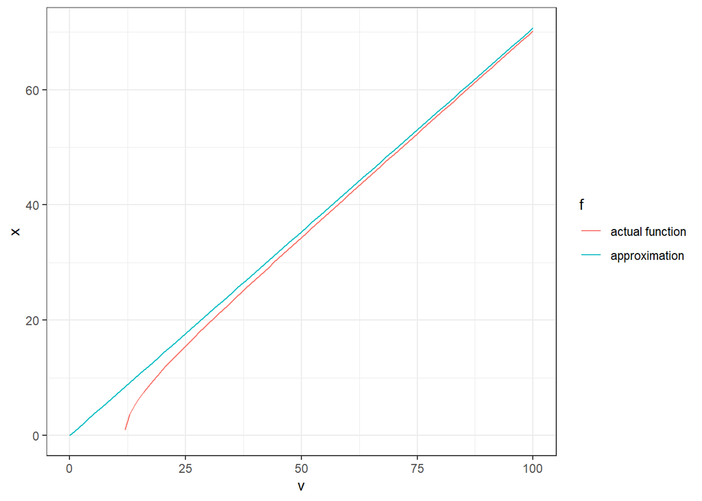

```r
v<-seq(0,100,1)
x<-sqrt(v^2/2-71)
d1<-data.frame(v,x)
d1$f<-"actual function"
v<-seq(0,100,1)
x<-sqrt(v^2/2)
d2<-data.frame(v,x)
d2$f<-"approximation"
d<-rbind(d1,d2)
d<-d[is.nan(d$x)==FALSE,]
plt<-ggplot(data=d,aes(x=v,y=x,color=f))+theme_bw()+geom_line()
plt
```

So it is not too terrible for reasonable kick speeds for college players, so it should work even better for NFL players. With the approximation, this becomes:
$$\begin{aligned}
x_h&\approx\frac{v^2\cos\rho\sin\rho+v^2\sin\rho\cos\rho}{g}\\
&=v^2\frac{\sin\rho\cos\rho}{g}
\end{aligned}$$

So the probability that the kick is above the crossbar at the right time is:
$$\begin{aligned}
\Pr(x<x_h)&=\Pr\left(x<v^2\frac{\sin\rho\cos\rho}{g}\right)\\
&=\Pr\left(v>\sqrt{\frac{gx}{\sin\rho\cos\rho}}\right)\\
&=1-F_v\left(\sqrt{\frac{gx}{\sin\rho\cos\rho}}\right)
\end{aligned}$$
where $F_v(\cdot)$ is the cdf of the distribution of $v$. I let this be $\log v \sim N(m,s^2)$. This allows the probability of success to look something like this:

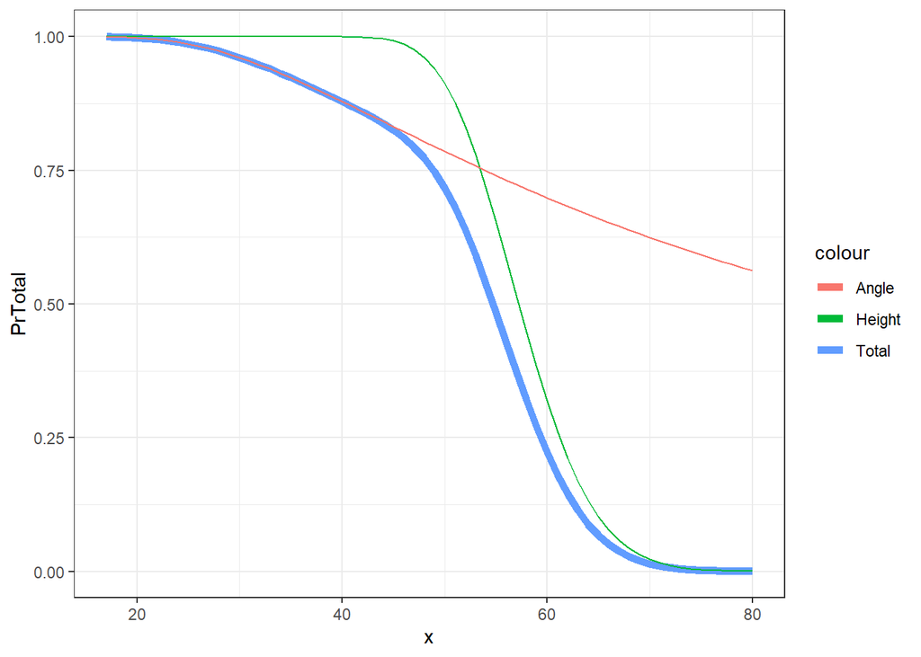

```r
x<-seq(17,80,1)
k<-1000
m<-log(35)
s<-0.05
# Distance between goal posts 18 feet 6 inches
d<-18.5/3
angle<-acos(x/sqrt(x^2+d^2/4))
pd<-data.frame(x,k,angle)
pd$PrAngle<-1-2*pbeta((-angle+pi/2)/pi, 0.5*k, 0.5*k)
pd$PrHeight<-1-pnorm(log(sqrt(10.7*x/0.5)),m,s)
pd$PrTotal<-pd$PrHeight*pd$PrAngle
pltdata<-pd

plt<-ggplot()+geom_line(data=pltdata,aes(x=x,y=PrTotal,color="Total"),size=2)+theme_bw()
plt<-plt+geom_line(data=pltdata,aes(x=x,y=PrHeight,color="Height"))+geom_line(data=pltdata,aes(x=x,y=PrAngle,color="Angle"))
plt
```

That is, success at close range is mostly about getting the angle right, and success at long range is mostly about distance. Furthermore, distance has the greatest marginal effect of this second probability at:
$$\begin{aligned}
0&=\sqrt{\frac{gx}{\sin\rho\cos\rho}}-m\\
m^2\sin\rho\cos\rho&=gx\\
x=\frac{m^2\sin\rho\cos\rho}{g}
\end{aligned}$$

The trouble I was having with this model was that so few attempts are made further than about 60 yards out. Even when I pooled the data from all years and all players, there was very little information about these parameters (and the predictions were terrible).